# R - Week 2, workshop 4

R for Bioinformatics: VCFs, PCAs, and the terminal

Dr Hannah Jackson

## Learning outcomes

By the end of the session, you should be able to:

- Understand and manipulate VCF files in R
  - the vcfR package: vcfR and chromR objects
  - Reading in and writing out VCF files
  - Querying and filtering VCFs
- Understand and perform Principal Components Analysis (PCA)
  - Prepping genomic data
  - Performing the PCA
  - Extracting and plotting results
- Running R scripts from the terminal

# VCFs

The whats, the whens, and the hows

## What is a VCF?

- **V**ariant **C**all **F**ormat (VCF)
- Text based file used to store variant information, relative to a reference genome (i.e. information about how and where things differ from a reference genome in a set of sequenced individuals)
- Developed by 1000 genomes project, now a standard file format
- Can represents SNPs, indels, structural variants etc for one or many samples

## What are they used for?

- Recording variants identified by variant calling proceedures
- Filtering and QC of variants based on things like quality, read depth
- Genotype analysis across individuals or populations
- Input for downstream analysis (for e.g. need a filtered .vcf for a GWAS)

## What does a VCF look like?

horrible!

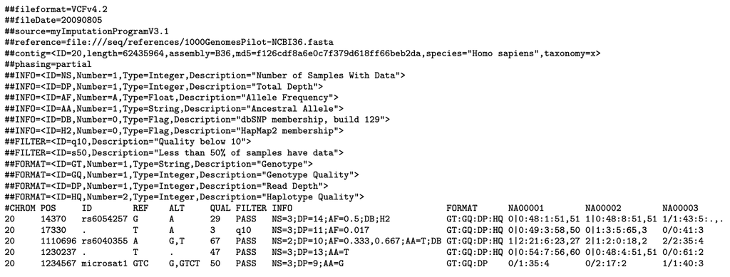

## But luckily standardised!

- Because the format is standardised, we can expect a whole series of information to be present in each .vcf that we encounter
- There are 3 main sections:
  - Comment lines/Metadata
  - Information block
  - Genotype data

## The comment lines:

- Info lines begin with ##, and contain loads of useful stuff:
  - file format
  - date
  - reference file that the variants are mapped to
  - source (i.e. how the file was created)
  - info about how to decode some columns (i.e. FORMAT GT = genotype)

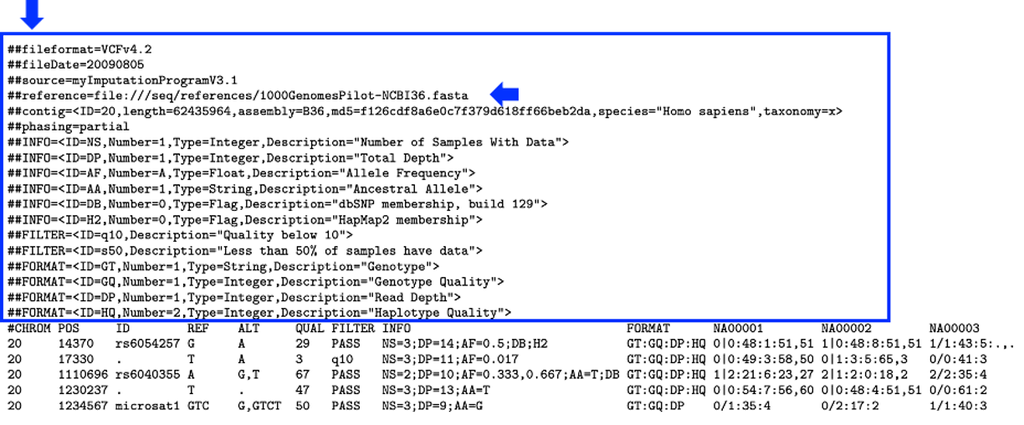

## The information block:

- This is where information about the variant site are stored
- Header line begins with #
- Standardised set of columns
  - CHROM = chromosome number/name
  - POS = position along chromosome (in bp)
  - ID = if it is a known variant (taken from databases, this can be blank)
  - REF = the base(s) present in reference genome

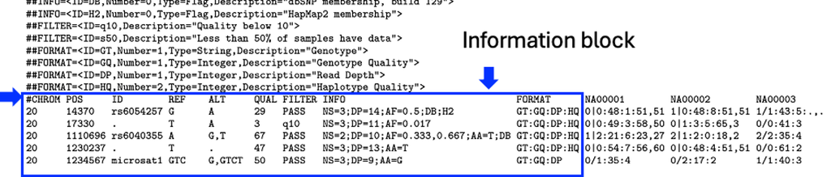

## The information block:

- Standardised set of columns
  - ALT = the alternate allele(s) present in samples
  - QUAL = quality, calculated from variant mapping
  - FILTER = any filters that are applied, usually based on quality for e.g. to remove rubbish SNPs
  - INFO = various bits of info abou thte SNP e.g. allele frequencies
  - FORMAT = the format which the data are in, can vary by row

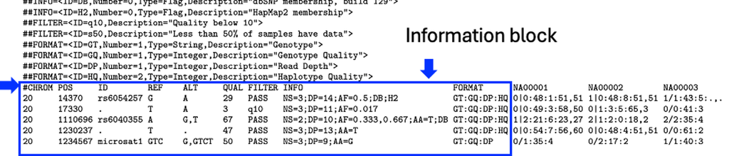

## The genotype data:

- The final section is the genotype data
- Oddly, the `FORMAT` column lives here
- Column name = individual/sample
- Info about the site/SNP for each sample, in format given in `FORMAT` column
- 0 = same as reference (i.e. no difference), 1 = alternate allele 1, 2 = alternate allele 2 etc
- Diploid, so copies of each chromosome, allele on each separated by /
- 0/0 = both alleles same as reference, 1/0 = copy 1 is alternate, 2 is reference etc

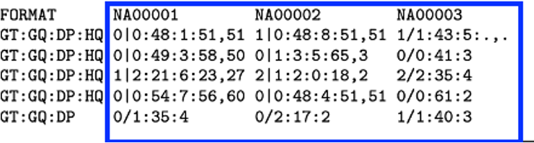

## The whole thing:

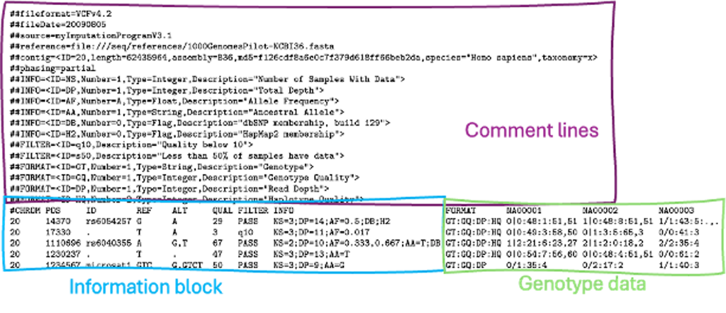

## VCFs and R

- VCF files and R play nicely, if you use the `vcfR` package
- You can read in VCF files, with the `read.vcfR()` function, we will try in a mo
- VCF files are read in as a new data class, similar to a list
- S4 data types are a class containing predefined named slots
- Slots are accessed differently to normal dataclasses, with `@` rather than `$`

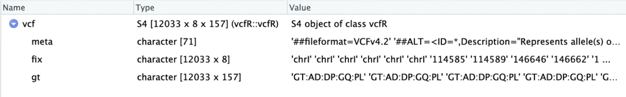

- - `meta` = metadata, the comment lines
  - `fix` = the fixed information (CHROM, POS, ID etc)
  - `gt` = genotype data

# Open your R windows and we’ll start exploring!

[figure not shown]

## Packages

install and library the `vcfR` package in the usual way

[figure not shown]

## Let’s read in a .vcf file

- Do a pull on the class repo if you haven’t already
- You should see a file called `stickleback_snps.vcf.gz`
- Let’s read it into R…
- Move it into your project directory
- `vcfR` has a function to do this for us: `read.vcfR()`
- note the .gz extension, this is just because the file is zipped!

```r
library(vcfR)
vcf <- read.vcfR("stickleback_snps.vcf.gz")
```

[output not shown]

## Let’s have a look:

```r
head(vcf)
```

```
[1] "***** Object of class 'vcfR' *****"
[1] "***** Meta section *****"
[1] "##fileformat=VCFv4.2"
[1] "##ALT=<ID=*,Description=\"Represents allele(s) other than observed.\">"
[1] "##FILTER=<ID=PASS,Description=\"All filters passed\">"
[1] "##FILTER=<ID=VQSRTrancheSNP99.00to99.50,Description=\"Truth sensitivi [Truncated]"
[1] "##FILTER=<ID=VQSRTrancheSNP99.50to99.90+,Description=\"Truth sensitiv [Truncated]"
[1] "##FILTER=<ID=VQSRTrancheSNP99.50to99.90,Description=\"Truth sensitivi [Truncated]"
[1] "First 6 rows."
[1]
[1] "***** Fixed section *****"
     CHROM  POS      ID REF ALT QUAL    FILTER
[1,] "chrI" "114585" NA "G" "A" "999"   "PASS"
[2,] "chrI" "114589" NA "G" "C" "16.59" "PASS"
[3,] "chrI" "146646" NA "G" "C" "999"   "VQSRTrancheSNP99.50to99.90"
```

[output cut: 24 more lines]

## Now we can find some info:

```r
class(vcf)
```

```
[1] "vcfR"
attr(,"package")
[1] "vcfR"
```

```r
dim(vcf)
```

```
variants fix_cols  gt_cols
   12033        8      157
```

```r
(vcf)
```

```
***** Object of Class vcfR *****
156 samples
20 CHROMs
12,033 variants
Object size: 90.4 Mb
0 percent missing data
*****        *****         *****
```

- `variants` tells us that there are 12033 data rows
- `fixed_cols` = 8 fixed info columns
- `gt_cols` = 156 fish (not 157 …why?)

## VCFs with vcfR

- Remember we can’t use `$` to access elements, we have to use `@`

```r
slotNames(vcf)
```

```
[1] "meta" "fix"  "gt"
```

```r
head(vcf@gt)
```

```
     FORMAT           Cist_16001              Cist_16002
[1,] "GT:AD:DP:GQ:PL" "0/1:5,3:8:50:57,0,76"  "0/1:2,1:3:6:12,0,46"
[2,] "GT:AD:DP:GQ:PL" "0/1:6,3:9:41:54,0,130" "0/0:3,1:4:4:9,0,81"
[3,] "GT:AD:DP:GQ:PL" "0/1:3,2:5:18:23,0,65"  "0/0:5,0:5:19:0,15,93"
[4,] "GT:AD:DP:GQ:PL" "0/0:4,0:4:22:0,12,76"  "0/0:4,1:5:5:6,0,66"
[5,] "GT:AD:DP:GQ:PL" "0/0:3,1:4:3:9,0,50"    "0/1:3,2:5:13:22,0,49"
[6,] "GT:AD:DP:GQ:PL" "0/0:4,0:4:18:0,12,95"  "0/0:4,0:4:18:0,12,75"
     Cist_16003             Cist_16004              Cist_16005
[1,] "0/0:3,0:3:15:0,9,80"  "0/1:7,2:9:15:21,0,168" "0/1:7,3:10:62:69,0,171"
[2,] "0/0:3,0:3:21:0,9,89"  "0/0:9,0:9:39:0,27,207" "0/0:11,0:11:45:0,33,255"
[3,] "0/1:4,1:5:3:5,0,50"   "0/0:6,0:6:22:0,18,112" "0/0:5,0:5:19:0,15,103"
[4,] "0/0:5,0:5:25:0,15,84" "0/0:6,0:6:28:0,18,112" "0/0:9,0:9:37:0,27,176"
[5,] "0/0:5,1:6:7:3,0,66"   "0/0:7,0:7:30:0,21,126" "0/0:9,0:9:36:0,27,180"
[6,] "0/1:3,2:5:16:23,0,39" "0/0:4,1:5:3:6,0,60"    "0/0:5,0:5:21:0,15,94"
     Cist_16007                Cist_16008              Cist_16009
```

[output cut: 405 more lines]

## Hang on…

- We’ve got this VCF file with a load of information in it, but what are we going to try and do?!
- Nothing too exciting yet (but wait until about 12:30…)
- Navigate the data structure
- Understand how it works
- Work out how to apply filters based on quality control metrics
- *THEN* we can move on to using the file to try and work out whether variation is associated with phenotypes!

## Back to the matter at hand!

- We can manipulate and filter VCFs within R
- If we look at the info from the file by typing the object name `vcf` we can see we have data from 156 fish here
- What if we want to select only a few??
- We can do this with standard indexing, as usual (`[]`)

```r
vcf2 <- vcf[,1:4]
```

- This will automatically apply to the `gt` matrix
- Note the `1:4` after the `,` - we want the first three fish, and samples are in columns

## Let’s have a look

```r
vcf2
```

```
***** Object of Class vcfR *****
3 samples
20 CHROMs
12,033 variants
Object size: 7.1 Mb
0 percent missing data
*****        *****         *****
```

```r
head(vcf2)
```

```
[1] "***** Object of class 'vcfR' *****"
[1] "***** Meta section *****"
[1] "##fileformat=VCFv4.2"
[1] "##ALT=<ID=*,Description=\"Represents allele(s) other than observed.\">"
[1] "##FILTER=<ID=PASS,Description=\"All filters passed\">"
[1] "##FILTER=<ID=VQSRTrancheSNP99.00to99.50,Description=\"Truth sensitivi [Truncated]"
[1] "##FILTER=<ID=VQSRTrancheSNP99.50to99.90+,Description=\"Truth sensitiv [Truncated]"
[1] "##FILTER=<ID=VQSRTrancheSNP99.50to99.90,Description=\"Truth sensitivi [Truncated]"
[1] "First 6 rows."
[1]
[1] "***** Fixed section *****"
     CHROM  POS      ID REF ALT QUAL    FILTER
[1,] "chrI" "114585" NA "G" "A" "999"   "PASS"
[2,] "chrI" "114589" NA "G" "C" "16.59" "PASS"
[3,] "chrI" "146646" NA "G" "C" "999"   "VQSRTrancheSNP99.50to99.90"
```

[output cut: 23 more lines]

## What if we want to filter by SNP?

- We might be interested in what a particular location on the genome looks like (perhaps we have suspicions that this is the location responsible for a phenotypic change?)
- We can filter by row in the usual way

```r
vcf2[1:3,]
```

```
***** Object of Class vcfR *****
3 samples
1 CHROMs
3 variants
Object size: 0 Mb
0 percent missing data
*****        *****         *****
```

```r
head(vcf2[1:3,])
```

```
[1] "***** Object of class 'vcfR' *****"
[1] "***** Meta section *****"
[1] "##fileformat=VCFv4.2"
[1] "##ALT=<ID=*,Description=\"Represents allele(s) other than observed.\">"
[1] "##FILTER=<ID=PASS,Description=\"All filters passed\">"
[1] "##FILTER=<ID=VQSRTrancheSNP99.00to99.50,Description=\"Truth sensitivi [Truncated]"
[1] "##FILTER=<ID=VQSRTrancheSNP99.50to99.90+,Description=\"Truth sensitiv [Truncated]"
[1] "##FILTER=<ID=VQSRTrancheSNP99.50to99.90,Description=\"Truth sensitivi [Truncated]"
[1] "First 6 rows."
[1]
[1] "***** Fixed section *****"
     CHROM  POS      ID REF ALT QUAL    FILTER
[1,] "chrI" "114585" NA "G" "A" "999"   "PASS"
[2,] "chrI" "114589" NA "G" "C" "16.59" "PASS"
[3,] "chrI" "146646" NA "G" "C" "999"   "VQSRTrancheSNP99.50to99.90"
[1]
[1] "***** Genotype section *****"
     FORMAT           Cist_16001              Cist_16002
[1,] "GT:AD:DP:GQ:PL" "0/1:5,3:8:50:57,0,76"  "0/1:2,1:3:6:12,0,46"
[2,] "GT:AD:DP:GQ:PL" "0/1:6,3:9:41:54,0,130" "0/0:3,1:4:4:9,0,81"
[3,] "GT:AD:DP:GQ:PL" "0/1:3,2:5:18:23,0,65"  "0/0:5,0:5:19:0,15,93"
     Cist_16003
[1,] "0/0:3,0:3:15:0,9,80"
[2,] "0/0:3,0:3:21:0,9,89"
[3,] "0/1:4,1:5:3:5,0,50"
[1]
[1] "Unique GT formats:"
[1] "GT:AD:DP:GQ:PL"
[1]
```

## What if we want to filter by individual fish?! 🐟

- If we know the names of the fish we want, we can create a vector of them… (remember to include format column)

```r
fish <- c("FORMAT", "Cist_16001", "Cist_16002", "Cist_16003")
```

- …and filter by it

```r
vcf[,fish]
```

```
***** Object of Class vcfR *****
3 samples
20 CHROMs
12,033 variants
Object size: 7.1 Mb
0 percent missing data
*****        *****         *****
```

## Or…

- We can declare the IDs of the fish directly inside the `[]`

```r
vcf[,c("FORMAT", "Cist_16001", "Cist_16002", "Cist_16003")]
```

```
***** Object of Class vcfR *****
3 samples
20 CHROMs
12,033 variants
Object size: 7.1 Mb
0 percent missing data
*****        *****         *****
```

[figure not shown]

## Querying VCFs

- There are several inbuilt functions that you can use to query interesting and useful stuff in your VCF file
- `is.biallelic`, `is.indel` are two e.g.s
- Let’s see if any of our fish SNPs are biallelic

```r
is.biallelic(vcf)
```

```
    [1]  TRUE  TRUE  TRUE  TRUE  TRUE  TRUE  TRUE  TRUE  TRUE  TRUE  TRUE  TRUE
   [13]  TRUE  TRUE  TRUE FALSE  TRUE  TRUE  TRUE  TRUE  TRUE  TRUE FALSE FALSE
   [25] FALSE  TRUE FALSE  TRUE  TRUE  TRUE FALSE  TRUE FALSE  TRUE  TRUE FALSE
   [37]  TRUE FALSE  TRUE  TRUE FALSE  TRUE  TRUE  TRUE  TRUE  TRUE  TRUE  TRUE
   [49]  TRUE  TRUE  TRUE  TRUE  TRUE  TRUE  TRUE  TRUE  TRUE  TRUE  TRUE  TRUE
   [61]  TRUE  TRUE  TRUE  TRUE  TRUE  TRUE  TRUE  TRUE  TRUE  TRUE  TRUE  TRUE
   [73]  TRUE  TRUE  TRUE  TRUE  TRUE  TRUE  TRUE  TRUE  TRUE  TRUE  TRUE  TRUE
   [85]  TRUE  TRUE  TRUE  TRUE  TRUE  TRUE  TRUE  TRUE  TRUE  TRUE  TRUE  TRUE
   [97]  TRUE  TRUE  TRUE  TRUE  TRUE  TRUE  TRUE  TRUE  TRUE  TRUE  TRUE  TRUE
  [109]  TRUE  TRUE  TRUE  TRUE  TRUE  TRUE  TRUE  TRUE  TRUE  TRUE  TRUE  TRUE
  [121]  TRUE  TRUE  TRUE  TRUE  TRUE  TRUE  TRUE  TRUE  TRUE  TRUE  TRUE  TRUE
  [133]  TRUE  TRUE  TRUE  TRUE  TRUE  TRUE  TRUE  TRUE  TRUE FALSE  TRUE  TRUE
  [145]  TRUE  TRUE  TRUE  TRUE  TRUE  TRUE  TRUE  TRUE  TRUE  TRUE  TRUE  TRUE
  [157]  TRUE  TRUE  TRUE  TRUE  TRUE  TRUE  TRUE  TRUE  TRUE  TRUE FALSE  TRUE
  [169]  TRUE  TRUE  TRUE  TRUE FALSE  TRUE  TRUE  TRUE  TRUE  TRUE  TRUE  TRUE
```

[output cut: 988 more lines]

## Woah..

- We can make the results look a bit nicer, by using `table()` to summarise for us

```r
table(is.biallelic(vcf))
```

```
FALSE  TRUE
  519 11514
```

- Either `TRUE` because there are 2 alleles (i.e. reference or alternate)
- or `FALSE` if there are more than 2
- those with no variation are not in the VCF file, as they are not variants!

## More querying

- We can also have a look and see if any of our SNPs are indel mutations

```r
table(is.indel(vcf))
```

```
FALSE
12033
```

- Note that there is no `TRUE`, which means that they are all false! (i.e. none of them are indels)

## Filtering with queries

- We can use the results of our query statements to filter our VCF.
- We might want to get hold of all of the SNPs that are biallelic (this is often necessary for downstream analysis)
- We would do that by using the `is.biallelic()` function inside of an index

```r
vcf2 <- vcf[is.biallelic(vcf),]
```

- Remember that SNPs are in rows, so the function comes before the comma in the index.
- If we wanted the opposite (i.e. only mulitiallelic), we’d just need to add a `!` before the `is.biallelic()` function

```r
vcf2 <- vcf[!is.biallelic(vcf),]
```

## Filtering with queries

```r
head(vcf2@gt)
```

```
     FORMAT           Cist_16001
[1,] "GT:AD:DP:GQ:PL" "1/1:2,14,0:16:8:85,10,0,91,42,103"
[2,] "GT:AD:DP:GQ:PL" "0/0:10,1,0:11:20:0,11,194,30,197,206"
[3,] "GT:AD:DP:GQ:PL" "0/0:9,1,0:10:11:0,8,183,27,186,195"
[4,] "GT:AD:DP:GQ:PL" "0/2:6,1,1:8:6:22,13,118,0,86,105"
[5,] "GT:AD:DP:GQ:PL" "0/0:12,0,0:12:35:0,36,244,36,244,244"
[6,] "GT:AD:DP:GQ:PL" "0/1:7,3,2:12:32:47,0,161,28,135,187"
     Cist_16002
[1,] "1/1:1,20,2:23:33:93,43,0,82,28,85"
[2,] "0/1:12,2,0:14:26:36,0,250,72,255,255"
[3,] "0/1:1,1,0:2:29:39,0,24,42,27,66"
[4,] "0/0:2,0,0:2:9:0,6,69,6,69,69"
[5,] "0/1:1,1,0:2:20:38,0,15,41,18,56"
[6,] "0/1:2,1,0:3:18:21,0,57,27,60,82"
     Cist_16003
```

[output cut: 930 more lines]

- Cist_16009 has a gt of 1/2

## Let’s recreate our biallelic vcf file

```r
vcf2 <- vcf[is.biallelic(vcf),]
```

- We can write it out of R using `write.vcf()`

```r
write.vcf(vcf2, "biallelic_stickleback.vcf.gz")
```

- Have a look and check that this file has been created in your project directory

## VCFs in R: ChromR objects

- We can do more complex stuff within `vcfR` by converting our vcfR objects into chromR objects
- The `chromR` object is an S4 class object with many slots!

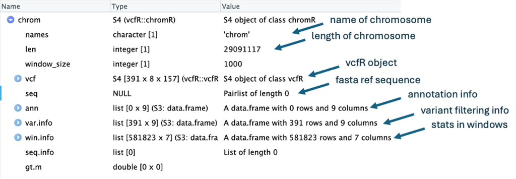

## VCFs in R: ChromR objects

- A ChromR object can only store information about a single chromosome, but has much more information available than a vcfR
  - name
  - length
  - window size in bp (more on that soon)
  - stats in windows
  - annotation info (none here)
  - fasta ref sequence
  - vcfR object
- Note that the chromR format stores all of the information from the original vcfR format within it

## Converting to chromR

- We use the `create.chromR()` function to create chromR files from our vcf

```r
chrom1 <- create.chromR(vcf, name = "chr")
```

- If you click on the object in your R window, you’ll see that we have all of the slots that we had before
- No info in the window sections, but we’ll add that soon..
- `create.chromR` defaults to chromosome 1, can either loop over them all or filter by chr if you want others!

## ChromR

- We can plot some info from this file to see what’s going on…

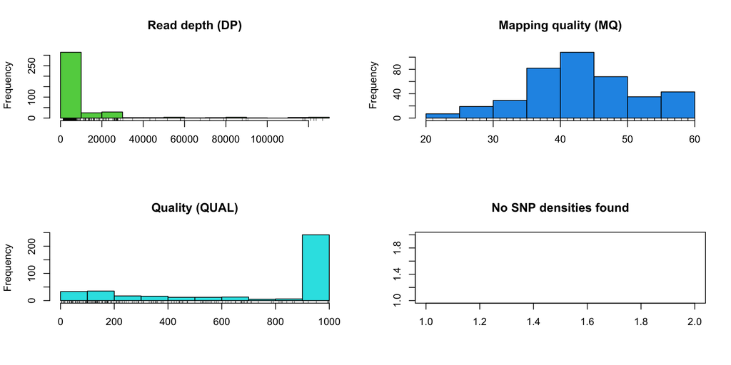

```r
plot(chrom1)
```

## ChromR

- ChromR files, and the plots from them, are useful QC checking tools
- Not always sure what the quality of our data are like, so this is helpful for filtering out bad variants for downstream analysis
- Plots: - Read depth - Mapping quality - Quality - SNP density

## QC diagnostics

1. Read depth:
- Each bar represents how many variant sites have a given depth (i.e. number of reads covering that position)
- Use it to check for uneven coverage or extreme depths (potential artefacts/repetitive regions)
2. Mapping quality:
- Reflects how confidently reads were aligned to reference
- Use it to assess overall reliability of read placement across variants

## QC diagnostics

3. Quality:
- Scores estimate the confidence that a site is truly a variant, rather than a sequencing or alignment error
- Use it to decide thresholds for filtering
4. SNP density:
- Number of SNPs per window along the chromosome
- Use it to ID areas of high or low variant density
- None here because no defined windows

## Masking

- `vcfR` allows us to filter by masking
- This means that the data remain in the dataset, but they are hidden from view
- We can check what masks are applied…

```r
table(chrom1@var.info$mask)
```

```
TRUE
 391
```

- All are `TRUE`, which means nothing is masked (we might expect this as we haven’t applied a mask yet!)

[figure not shown]

## Masking

- We’ll apply a mask, and hide some of the lower quality SNPs
- Use `masker()` function to do this, inc arguments defining quality metric cutoffs

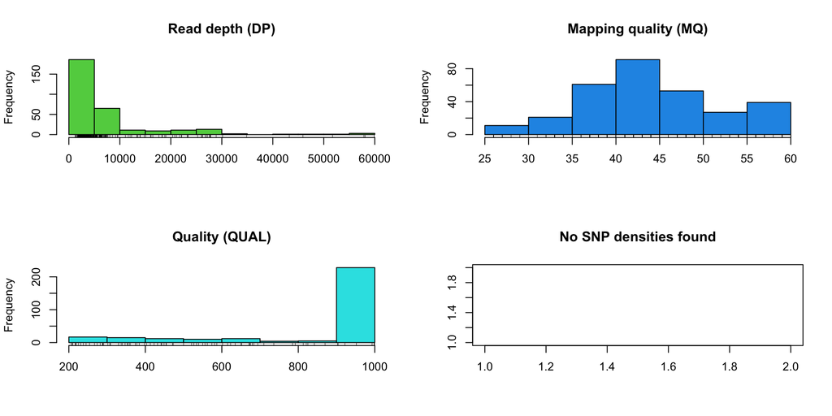

```r
chrom1 <- masker(chrom1, min_QUAL = 200,
                         min_DP = 100,
                         max_DP = 60000,
                         min_MQ = 25)

plot(chrom1)
```

## Masking

- We’ve overwritten chrom1, so let’s have a look and check (to back up our plots) that our masks were definitely applied

```r
table(chrom1@var.info$mask)
```

```
FALSE  TRUE
   88   303
```

- Our masking attempt was sucessful!
- Remember that just because we have overwritten the dataset, we have not lost any information from it

## Windows

- Windows are fixed-length segments of chromosome (measured in bp)
- They are used to summarise variant data along the genome
- for e.g. to calculate SNP desnsity or mean depth per genomic region
- The window size is arbitrary
- Windows useful for summarising information in a computationally efficient way (e.g. if your window is 1000bp, you have 1/1000 of the data)
- Check window info with

```r
chrom1@win.info
```

```
data frame with 0 columns and 0 rows
```

- This is empty as we have not yet defined the windows

## Windows

- We can tell R to create data summaries based on a window size with `proc.chromR`
- This function is to process chromR objects
- We use the `winsize` argument to define window size

```r
chrom1 <- proc.chromR(chrom1, win.size = 500)
chrom1@win.info
```

```
      CHROM window   start     end length genic variants
1      chrI      1       1     500    500     0        0
2      chrI      2     501    1000    500     0        0
3      chrI      3    1001    1500    500     0        0
4      chrI      4    1501    2000    500     0        0
5      chrI      5    2001    2500    500     0        0
6      chrI      6    2501    3000    500     0        0
7      chrI      7    3001    3500    500     0        0
8      chrI      8    3501    4000    500     0        0
9      chrI      9    4001    4500    500     0        0
10     chrI     10    4501    5000    500     0        0
11     chrI     11    5001    5500    500     0        0
12     chrI     12    5501    6000    500     0        0
13     chrI     13    6001    6500    500     0        0
14     chrI     14    6501    7000    500     0        0
```

[output cut: 14272 more lines]

## Windows

- We now have several window summary stats that we can plot

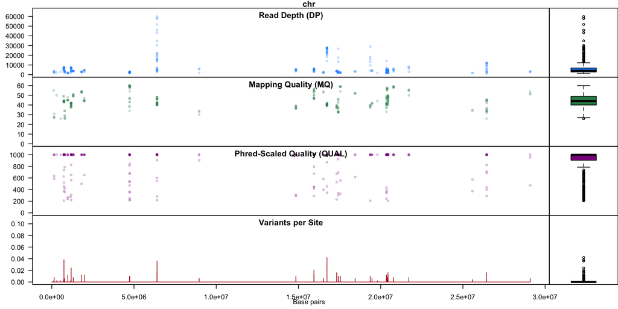

```r
chromoqc(chrom1, dp.alpha = 50)
```

## Windows

- These plots all tell us something about the quality of our data
- Windowed stats are super useful QC checks
- Also good for spotting where something might be going on!
- This data is fairly low coverage with lots of holes, but still tells us something

## Writing out VCFs

- We can also write out VCF files, including or excluding the mask
- If mask is included, masked SNPs are not written, so will not be present in the written out data
- The default is mask = F

```r
write.vcf(chrom1, mask = T, "filtered_stickleback_snps.vcf.gz")
```

- Now we can take this file and use it elsewhere!

## Have a go…

1. Read the VCF file Volucella_bombylans.vcf.gz from the git into your R environment (make sure you give it a different name or you will overwrite the other VCF we’ve been working with)
2. Print the dimensions of the VCF to your R console
3. Filter the vcf so that it contains only the three individuals: VB20001, VB20005 and VB21020 (remember you will also need to retain the format column)
4. Query the VCF to see how many sites are biallelic, output the result as a table
5. Query the VCF to see how many sites are indels, output the result as a table
6. Show how you would filter the VCF to contain only sites that are NOT indels
7. Convert your vcfR object to chromR format and plot some general stats on the chromR object (make sure you give your new chromR object a different name too)
8. **Brucey bonus:** Create a mask to filter your ChromR object - use plots from q7 to guide you about where to set thresholds. Write your filtered vcf to a new file with a different name

# PCA

## PCA

- **P**rincipal **C**omponents **A**nalysis
- Method for dimensionality reduction in large datasets
- Takes series of correlated variables and flattens into new ones:
  - capture the main patterns of variation
  - uncorrelated/orthoganol axes
- PC1 is optimised to explain the highest possible amount of variance in the data
- Useful for visualising and exploring patterns in data
- Use on any continuous data

## PCA

- Can reveal clusters, gradients, or outliers
- Used in genomics to:
  - identify population structure
  - detect batch effects
  - summarise multivariate data
- PCA scores = position of each individual or sample along each PC axis
- Loadings = variable contributions to each PC (i.e. how much each variable is contributing to variation explained in that axis)

## PCA

- Here, we’re going to use PCA to have a look at whether SNP variant data from a VCF file cluster in a meaningful way
- Start from a .vcf.gz dataset with variation at multiple SNP sites in a chromosome
- Collapse correlated variables into few axes of variation
- Plot these new variables
- Identify clusters (by eye)
- Do the clusters correspond to anything we know about the samples?

## PCA in R

- There are lots of ways to perform a standard PCA in R
- We are using the `adegenet` package, so install and library it now…
- vcf.gz file on git, `Volucella_bombylans.vcf.gz`
- data is a VCF file pertaining to several bumblebee hoverfly mimic individuals collected in the UK

[figure not shown]

## PCA in R

- Read in the vcf file with `read.vcfR`

```r
vcf2 <- read.vcfR("Volucella_bombylans.vcf.gz")
```

[output not shown]

## Getting the data ready…

- Now we need to extract only the genotype matrix, the other information is not relevant to the PCA!
- `extract.gt()` function will do this for us

```r
mat <- extract.gt(vcf2)
head(mat)
```

```
         VB20001 VB20002 VB20003 VB20004 VB20005 VB20006 VB21001 VB21002
5_2748   "0/0"   "0/0"   "0/0"   "0/0"   "0/0"   "0/0"   "0/0"   "0/0"
5_54307  "0/0"   "0/0"   "0/0"   "0/0"   "0/0"   "0/0"   "0/0"   "0/0"
5_109813 "0/0"   "0/0"   "0/0"   "0/0"   "0/0"   "0/1"   "0/0"   "0/0"
5_161021 "0/0"   "0/0"   "0/0"   "0/0"   "0/0"   "0/0"   "0/0"   "0/0"
5_213912 "0/0"   "0/0"   "0/1"   "0/0"   "0/0"   "0/0"   "0/0"   "0/0"
5_268024 "0/0"   "0/0"   "0/0"   "0/0"   "0/0"   "0/0"   "0/0"   "0/0"
         VB21003 VB21004 VB21005 VB21006 VB21007 VB21008 VB21009 VB21010
5_2748   "0/0"   "0/0"   "0/0"   "0/0"   "0/0"   "0/0"   "0/0"   "0/0"
5_54307  "0/0"   "0/0"   "0/0"   "0/0"   "0/0"   "0/0"   "0/0"   "0/0"
5_109813 "0/0"   "0/0"   "0/0"   "0/0"   "0/0"   "0/0"   "0/0"   "0/0"
5_161021 "0/0"   "0/0"   "0/0"   "0/0"   "0/0"   "0/0"   "0/0"   "0/0"
5_213912 "0/0"   "0/0"   "0/0"   "0/0"   "0/0"   "0/0"   "0/0"   "0/0"
5_268024 "0/0"   "0/0"   "0/0"   "0/0"   "0/0"   "0/0"   "0/0"   "0/0"
         VB21011 VB21012 VB21013 VB21014 VB21015 VB21016 VB21017 VB21018
5_2748   "0/0"   "0/0"   "0/0"   "0/0"   "0/0"   "0/0"   "0/0"   "0/1"
5_54307  "0/0"   "0/0"   "0/0"   "0/0"   "0/0"   "0/0"   "0/0"   "0/0"
5_109813 "0/0"   "0/0"   "0/0"   "0/0"   "0/0"   "0/0"   "0/0"   "0/0"
5_161021 "0/1"   "0/0"   "0/0"   "0/0"   "0/0"   "0/0"   "0/0"   "0/0"
5_213912 "0/0"   "0/0"   "0/0"   "0/0"   "0/0"   "0/0"   "0/0"   "0/0"
5_268024 "0/0"   "0/0"   "0/0"   "0/0"   "0/0"   "0/0"   "0/0"   "0/1"
         VB21019 VB21020 VB21021 VB21022 VB21023 VB21024 VB21025 VB21026
5_2748   "0/0"   "0/0"   "0/0"   "0/0"   "0/0"   "0/0"   "0/0"   "0/0"
5_54307  "0/0"   "0/0"   "0/0"   "0/0"   "0/0"   "0/0"   "0/1"   "0/0"
5_109813 "0/0"   "0/0"   "0/0"   "0/0"   "0/0"   "0/0"   "0/0"   "0/0"
5_161021 "0/0"   "0/0"   "0/0"   "0/0"   "0/0"   "0/1"   "0/0"   "0/0"
5_213912 "0/0"   "0/0"   "0/0"   "0/0"   "0/0"   "0/0"   "0/0"   "0/0"
5_268024 "0/0"   "0/0"   "0/0"   "0/0"   "0/0"   "0/0"   "0/0"   "0/0"
         VB21027 VB21028 VB21029 VB21030 VB21031 VB21032 VB21033 VB21034
5_2748   "0/1"   "0/0"   "0/0"   "0/0"   "0/0"   "0/0"   "0/1"   "0/0"
5_54307  "0/0"   "0/0"   "0/0"   "0/0"   "0/0"   "0/0"   "0/0"   "0/0"
5_109813 "0/0"   "0/0"   "0/0"   "0/0"   "0/0"   "0/0"   "0/0"   "0/0"
5_161021 "0/0"   "0/0"   "0/0"   "0/0"   "0/0"   "0/0"   "0/0"   "0/0"
5_213912 "0/0"   "0/0"   "0/0"   "0/0"   "0/0"   "0/0"   "0/0"   "0/0"
5_268024 "0/0"   "0/0"   "0/0"   "0/0"   "0/0"   "0/0"   "0/0"   "0/0"
         VB21035 VB21036 VB21037
5_2748   "0/0"   "0/0"   "0/0"
5_54307  "0/0"   "0/0"   "0/0"
5_109813 "0/0"   "0/0"   "0/0"
5_161021 "0/0"   "0/1"   "0/0"
5_213912 "0/0"   "0/0"   "0/0"
5_268024 "0/0"   "0/0"   "0/0"
```

## Getting the data ready…

- Now we have just the `gt` parts of the data, but as a matrix
- Currently, the SNPs are the rows, and the individuals are the columns
- Individuals must be treated as the observations (rows)
- We need to transpose our data (more on why on the next slide)

```r
mat <- t(mat)
```

## Why the transpose?

- Each SNP (or variable) contributes some information about how individuals differ genetically
- Many SNPs are correlated, for e.g. nearby loci may be in linkage so share similar allele frequencies due to lack of recombination
- PCA looks for combinations of variables which capture the main axis of variation
- The point of this PCA is that it will reduce thousands of correlated SNPs into a efw axes which best summarise how individuals differ across the genome at large
- We have to transpose the data, as the SNPs are no longer the observations, but the variables themselves

## Back to it!

- Now that we’ve transposed our matrix, we can use the `adegenet` package to perform our PCA!
- First, we need to convert our matrix into an object type that `adegenet` recognises
- Thankfully, the package provides the functions to do that…

```r
library(adegenet)
gen <- df2genind(mat, sep = "/")
```

- `df2genind` means dataframe to genind (genetic individual), the name of the object
- The sep argument tells R how our alleles are separated in the original VCF file
- We want to be able to identify individuals, so this needs to be a column, rather than just the row names (all will be revealed)
- We do this with `row.names()`

```r
gen <- df2genind(mat, sep = "/", ind.names(row.names(mat)))
```

## Allele frequencies

- The PCA needs to know the frequency with which alleles appear
- This is because PCA analyses shared variation between variables (i.e. when two or more variables change in similar ways across individuals/are correlated)
- If we use SNP count, as our data is formatted now, differences in sample size between alleles would skew the data
- To calculate allele frequencies, we use the `tab()` function

```r
allele_freq <- tab(gen, freq = T, NA.method = "mean")
```

- `NA.method = "mean"` means that missing values will be replaced by the mean allele frequency at that locus for all other individuals. Interpolates data from other individuals.

## PCA!

- Now we have all our data in order, we can perform our PCA!
- We do this using the `dudi.pca()` function

```r
pca <- dudi.pca(allele_freq, center = T, scale = F)
```

- Our input data are our allele frequencies
- center = T - subtracts the mean value of each variable (e.g. mean allele frequency at each locus) so that every variable has a mean of zero.
  - This recentres the data cloud around the origin, allowing PCA to capture variation around the average, not the absolute values.
  - Without centering, PCA would be dominated by loci or variables with large means, rather than those that actually vary between individuals.
- scale = F - we would only need to scale our PCA if variables were measured on vastly different scales, i.e. kilometers vs microns

## R asks us for input?!

- This is unusual
- R wants to know how many PCs to keep, based on a plot it has produced
- Helpfully, there are no axes labels, but the plot is showing the amount of the total variation (100%) explained by each new axis in turn

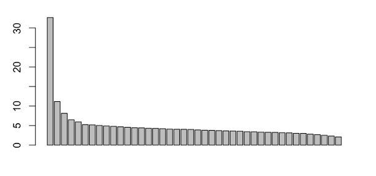

## PC selection

- On average, you’d expect each PC to explain a small amount of variation
- A PCA will output as many PCs are there are original variables, at random each would explain 1/n of the variation
- We only want the ones that explain much more than that!
- We’ll select just 1 and 2 here
- Don’t worry about PC selection, Tom will teach you more about that later…

## Without input

- R tells you what code you’d need to repeat this result non-interactively
- Make a note of it, as you can’t always use interactivity (for e.g. I can’t interact with the code that runs in these slides!!!)

## PCA

We can look at some information about the PCA with `summary()`

```r
summary(pca)
```

```
Class: pca dudi
Call: dudi.pca(df = allele_freq, center = T, scale = F, scannf = F,
    nf = 2)

Total inertia: 204

Eigenvalues:
    Ax1     Ax2     Ax3     Ax4     Ax5
 32.676  11.169   8.129   6.479   5.948

Projected inertia (%):
    Ax1     Ax2     Ax3     Ax4     Ax5
 16.015   5.474   3.984   3.176   2.915

Cumulative projected inertia (%):
    Ax1   Ax1:2   Ax1:3   Ax1:4   Ax1:5
  16.02   21.49   25.47   28.65   31.56

(Only 5 dimensions (out of 42) are shown)
```

## PCA

- Now we have two new variables which capture 22% of the total variation in the genome.
- We could look at what SNPs contribute to this if we wanted to, but we wont
- Be aware that different SNPs are correlated differently to each axis (variation at some SNPs will impact PC1 scores highly, others very little)
- Each individual has been given a PC score for each axis. This indicates where they sit along these new axes
- You can then use the information about which SNPs make up which axis to make inferences about the underlying biology

## PCA

- We can also plot the PC axes and see if we find any clusters of samples…
- First, we have to extract the scores and pop them in a dataframe

```r
pca_scores <- pca$li
head(pca_scores)
```

```
             Axis1       Axis2
VB20001 -12.850452 -0.03734278
VB20002 -12.527920 -0.40611397
VB20003 -12.576107 -0.57214328
VB20004 -13.295643  0.20850416
VB20005  -5.229026  0.50020446
VB20006   2.709025  2.37122864
```

- Currently our row names are not a variable, but we need them to be to match some sample data we will add later
- We can extract them with `row.names`

```r
pca_scores$Individual <- row.names(pca_scores)
head(pca_scores)
```

```
             Axis1       Axis2 Individual
VB20001 -12.850452 -0.03734278    VB20001
VB20002 -12.527920 -0.40611397    VB20002
VB20003 -12.576107 -0.57214328    VB20003
VB20004 -13.295643  0.20850416    VB20004
VB20005  -5.229026  0.50020446    VB20005
VB20006   2.709025  2.37122864    VB20006
```

## Plotting!

- let’s have a look at the plot of our two new axes

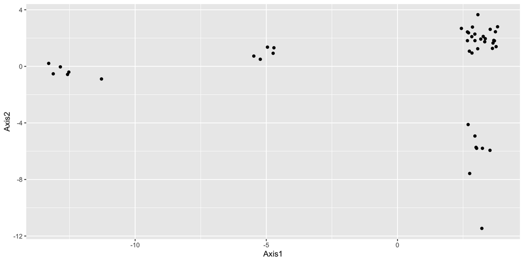

```r
library(ggplot2)
ggplot(aes(x = Axis1, y = Axis2), data = pca_scores)+
  geom_point()
```

## Plotting!

- We can see some clusters in our data, whatever SNPs are contributing to the PCs seem to be shared amongst some individuals!
- What could be causing it?
- We have some more information about the individuals in the `phenotype_covariates.csv` data
- Let’s read it in…

```r
ptcv <- read.csv("phenotype_covariates.csv")
head(ptcv)
```

```
  Individual Sex Latitude Location
1    VB21001   M 53.07735   FenBog
2    VB21002   M 53.20280   FenBog
3    VB21003   F 53.20579   FenBog
4    VB21004   M 53.20531   FenBog
5    VB21005   M 53.20468   FenBog
6    VB21006   F 53.20497   FenBog
```

## Merging datasets

- Now we need to merge the datasets together using `merge()`
- The merge function needs a way of matching entries
- We will use individual ID (which is why we needed it to not be a row name earlier!)
- The columns must have the same name in each dataframe

```r
merged_pca_data <- merge(pca_scores, ptcv, by = "Individual")
head(merged_pca_data)
```

```
  Individual      Axis1       Axis2 Sex Latitude  Location
1    VB20001 -12.850452 -0.03734278   F  54.4674    Warsop
2    VB20002 -12.527920 -0.40611397   F  54.4674    Warsop
3    VB20003 -12.576107 -0.57214328   M  54.4674    Warsop
4    VB20004 -13.295643  0.20850416   M  54.4674    Warsop
5    VB20005  -5.229026  0.50020446   M  54.4674    Warsop
6    VB20006   2.709025  2.37122864   M  54.4674 Southwell
```

## Plotting!

- Now we can recreate the plot, but colour points by the data in the phenotype file

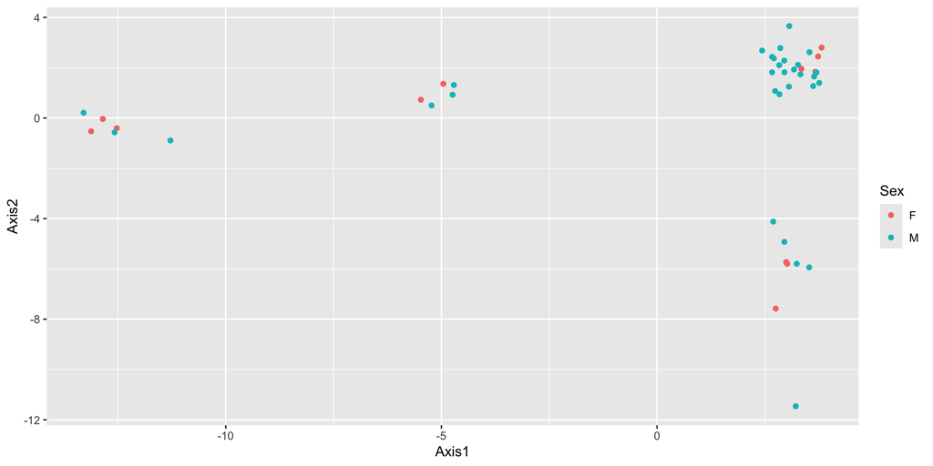

```r
ggplot(data = merged_pca_data, aes(x = Axis1, y = Axis2, colour = Sex))+
  geom_point()
```

## Let’s try location?

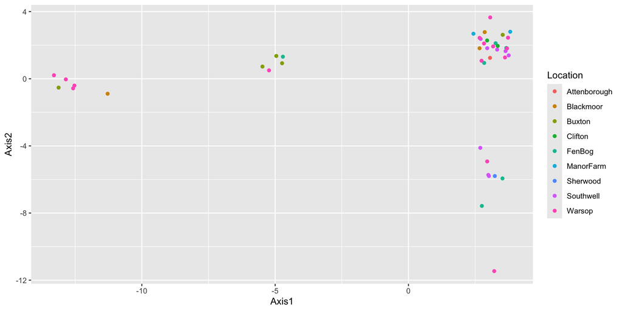

```r
ggplot(data = merged_pca_data, aes(x = Axis1, y = Axis2, colour = Location))+
  geom_point()
```

## What about latitude?

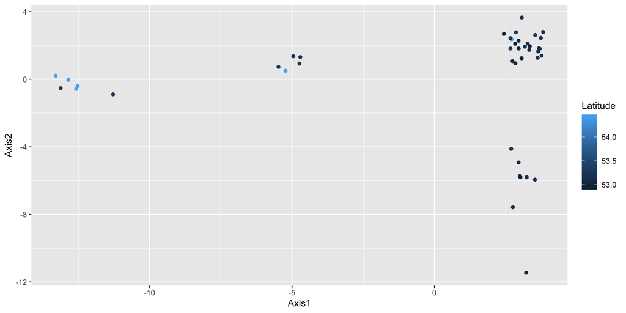

```r
ggplot(data = merged_pca_data, aes(x = Axis1, y = Axis2, colour = Latitude))+
  geom_point()
```

## What does it mean?

- None of the three variables map perfectly to the clusters
- Maybe lattitude a little bit? Does this mean that whatever variation is present in the SNPs is because of lattitude? Maybe partly?
- This is the fun bit! We still have questions to answer!!!!

# Running R scripts from the terminal

## Easy peasy lemon squeezy

- Well, at least if you’re a mac user
- Just open a terminal and use the `Rscript` function with the name of your script
- `Rscript my_script.R`
- WSL users it’s a bit trickier - can’t see your R install in the subsystem
- Laura (superhero) has created a new conda env, use the .yml on the git to create it (like you did with the lectures env before), and then you should be able to use it! (remember your .R scripts will have to be in the partition though)

# Speaking of questions

## Have a go…

Create an R script to perform a PCA on the stickleback VCF, and save the plot. Test and run your script from the terminal using `Rscript`.

**Hints**:

1. Remember to load your libraries
2. Give the full path to your files
3. Make the PCA command non-user input…

# Next time:

- Python!

[figure not shown]